# Partie II - Exploration de données du système Ford GoBike

## Par Medi Vankembo

## Aperçu de l'enquête

Ford GoBike est un système de données qui comprend des informations sur les trajets individuels effectués dans un système de partage de vélos. Avec environ 20 000 vélos et plus de 1 300 stations, Il a été conçu pour les déplacements rapides et pratiques, et constitue un moyen amusant et abordable de se déplacer en ville.

Sur ce, notre étude a porté sur les durées de courses.

Nous avons voulu donc comprendre comment les autres caractéristiques ont une influence sur ces durées.

## Vue d'ensemble des données

Pour cette analyse, les données récoltées ont concernées les courses enregistrées au mois de Février 2019, et constituées de 183412 enregistrements et 16 colonnes relatives aux durée de trajets parcourus, au stations de départ et d'arrivée(coordonnées géographiques, nom, id), aux vélo(type de velo, id), et aux utilisateurs(Date de naissance, sexe,...).

## 1. Influence des jours de la semaine sur les durées des courses

Nous avons réparti les courses selon les jours de la semaine afin d'appréhender son comportement, et le résultat nous a donné un classement qui ressemble à ceci :

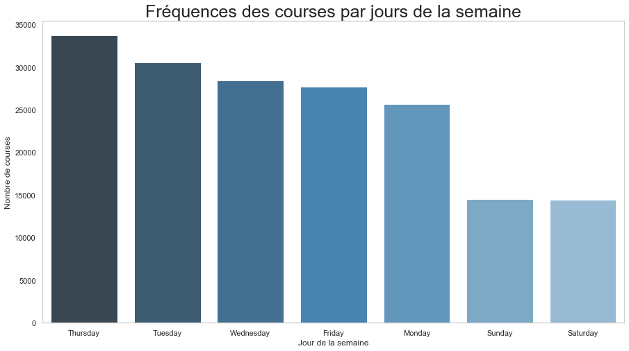

```python
# Plot the distribution
plt.figure(figsize=[15, 8])

# Set color
sb.set(style="whitegrid", color_codes=True)
pal = sb.color_palette("Blues_d", 7)

colors = ['#1b9e77', '#a9f971', '#fdaa48','#6890F0','#A890F0']
# sb.barplot(weekday_values.index.values, weekday_values, color=base_color, order=weekday_values_order)
sb.barplot(weekday_values.index.values, weekday_values, palette=np.array(pal[::-1]), order=weekday_values_order, )

# Selecting the axis-X making the bottom and top axes False.

plt.ylabel('Nombre de courses')
plt.xlabel('Jour de la semaine');
plt.grid(b=False)
plt.title('Fréquences des courses par jours de la semaine', fontsize=25);
```

Mais lorsque nous analysons les durées des courses en fonction des jours de la semaine nous obtenons le résultat suivant :

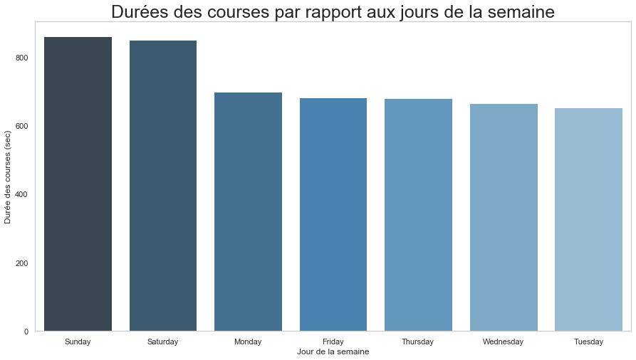

```python
# Plot
plt.figure(figsize=[15, 8])

# Set color
sb.set(style="whitegrid", color_codes=True)
pal = sb.color_palette("Blues_d", 7)

durations_mean_values = ford_go_bike.groupby(['start_weekday'], as_index=False)['duration_sec'].mean()

durations_mean_values_sorted = durations_mean_values.sort_values('duration_sec', ascending=False)

sb.barplot(data=durations_mean_values_sorted, y='duration_sec', x='start_weekday', palette=np.array(pal[::-1]), color=base_color)
plt.ylabel('durée (sec)');

plt.ylabel('Durée des courses (sec)')
plt.xlabel('Jour de la semaine');
plt.grid(b=False)
plt.title('Durées des courses par rapport aux jours de la semaine', fontsize=25);
```

Nous sommes arrivés à la conclusion que même si moins de courses à vélo sont effectuées les jours de week ends, elles sont réalisées sur des longues durées que pour les autres jours de la semaine.

En d'autres termes, plus nous avons des week ends, plus on a des courses de longues durées, et moins on a des jours de week end, moins on a des courses de longues durées.

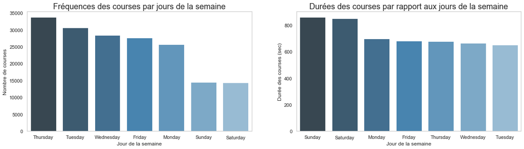

```python
# Plot the distribution
plt.figure(figsize=[20, 5])

# Set color
sb.set(style="whitegrid", color_codes=True)
pal = sb.color_palette("Blues_d", 7)

# First subplot
plt.subplot(1, 2, 1)
sb.barplot(weekday_values.index.values, weekday_values, palette=np.array(pal[::-1]), order=weekday_values_order, )


plt.ylabel('Nombre de courses')
plt.xlabel('Jour de la semaine');
plt.grid(b=False)
plt.title('Fréquences des courses par jours de la semaine', fontsize=18);

# Second subplot
plt.subplot(1, 2, 2)
durations_mean_values = ford_go_bike.groupby(['start_weekday'], as_index=False)['duration_sec'].mean()

durations_mean_values_sorted = durations_mean_values.sort_values('duration_sec', ascending=False)

sb.barplot(data=durations_mean_values_sorted, y='duration_sec', x='start_weekday', palette=np.array(pal[::-1]), color=base_color)
plt.ylabel('durée (sec)');

plt.ylabel('Durée des courses (sec)')
plt.xlabel('Jour de la semaine');
plt.grid(b=False)
plt.title('Durées des courses par rapport aux jours de la semaine', fontsize=18);
```

## 2. Influence des durées des sources par les types de vélo et les âges des utilsteurs

Pour savoir qui réalisent plus des courses de longues durées et avec quel type de vélo, nous nous sommes aussi intéressés à l'âge des cyclistes et aux types de vélo qu'ils utilisent, et nous sommes arrivés aux résultat suivants :

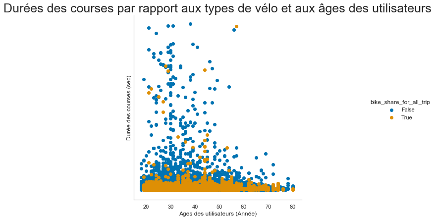

```python
g = sb.FacetGrid(data = ford_go_bike, hue = 'bike_share_for_all_trip', size = 6, palette = 'colorblind');
g.map(plt.scatter, 'user_age', 'duration_sec');
g.add_legend();

# Selecting the axis-Y making the right and left axes False
plt.tick_params(axis='y', which='both', right=False,
                left=False, labelleft=False)
plt.ylabel('Durée des courses (sec)')
plt.xlabel('Ages des utilisateurs (Année)');
plt.grid(b=False);
plt.title('Durées des courses par rapport aux types de vélo et aux âges des utilisateurs', fontsize=25);
```

Ce graphique nous montre que presque la totalité de courses sont réalisées avec des vélos qui ne sont pas pour tous types de trajets, et aussi par des cyclistes dont les âges varient entre 25 et 45 ans.

Donc plus on avance en âge, plus les durées de courses diminuent, et plus on a des vélos qui ne sont pas pour tous types de travaux, plus on effectue des courses de longues durées.

## 3. Influence des durées des courses par les types de cyclistes et leurs sexes

Notre désire est de voir plus de gens utiliser les moyens de déplacement plus responsables et écologiques tant que possible.  
Sur ce, nous avons besoin de savoir l'influence qu'ont les types de cyclistes et le sexe sur la durée des courses afin de mener une campagne spécifique sur l'usage des vélos dans notre quotidien.  
Et nos analyses nous montrent ce qui suit :

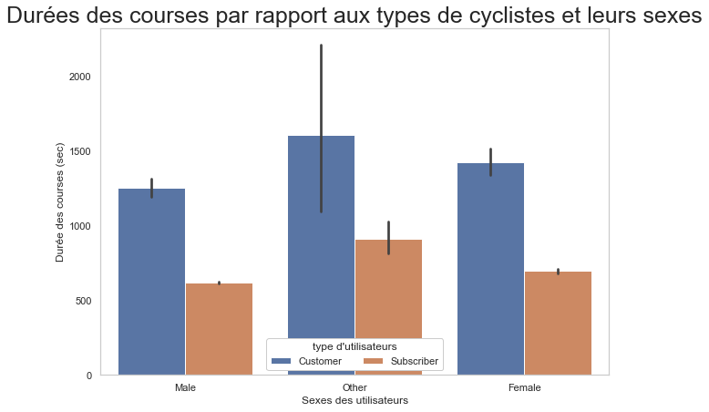

```python
plt.figure(figsize=[10, 7]);
ax = sb.barplot(data = ford_go_bike, x = 'member_gender', y = 'duration_sec', hue = 'user_type')
ax.legend(loc = 8, ncol = 3, framealpha = 1, title = "type d'utilisateurs")
plt.ylabel('durée des courses (sec)')
plt.xlabel('genres des utilisateurs')

#plt.tick_params(axis='y', which='both', right=False,
#                left=False, labelleft=False)
plt.ylabel('Durée des courses (sec)')
plt.xlabel('Sexes des utilisateurs');
plt.grid(b=False);
plt.title('Durées des courses par rapport aux types de cyclistes et leurs sexes', fontsize=25);
```

## Conclusion

Après avoir réalisé cette analyse, nous avons compris que plusieurs caractéristiques entre en jeu et influencent les durées de courses, notamment les **jours de la semaine**, l'**âge des utilisateurs**, le **type de vélo**, les **sexes d'utilisateurs**, les **types d'utilisateur**

Notre rôle est alors de mener une politique stratégique en se servant de ces éléments afin d'inciter la population à réaliser plus de courses de longues durées, ce qui est responsable, écologique et peu coûteux, bénéfique pour chaque partie.